# History of the Environment in Economic Thought

HEKA22—Lecture 3

Jonas Kreutzer

2026-05-15

# Learning Objectives

**By the end of today’s lecture you should:**

1. Be able to list the main historical figures that have shaped ecological and mainstream economics
2. Be able to understand key economic ideas to describe human use of nature and differentiate them based on their historical origins
3. Be able to create requirements for new economic theories based on ecological insights

# Classical Economics

Economics grows out of moral philosophy 1750–1870

## The economy as flow from nature

[figure not shown]

## The economy as flow from nature

[figure not shown]

François Quesnay

[figure not shown]

*Tableau économique* (1758)

François Quesnay & the Physiocrats, mid-18th c. France

## The Wealth of Nations: Gold or People?

[figure not shown]

“Ivan the Terrible Showing His Treasures to English Ambassador Jerome Horsey” – Alexander Litovchenko

## The Wealth of Nations: Gold or People?

[figure not shown]

Adam Smith — Muir portrait, c. 1800

> It is not from the benevolence of the butcher, the brewer, or the baker, that we expect our dinner, but from their regard to their own interest.

Smith, *Wealth of Nations* (1776), Bk I, Ch. II

## The first model of limits

[figure not shown]

Paul Louis Delance - Esquisse pour le cabinet du préfet de l’Hôtel de Ville de Paris , La Famine

## The first model of limits

[figure not shown]

Malthus — portrait by John Linnell, 1833

> Population, when unchecked, increases in a geometrical ratio. Subsistence increases only in an arithmetical ratio.

Malthus, *Essay on the Principle of Population* (1798), Ch. 1

## Rent and the marginal-land logic

[figure not shown]

Ricardo — portrait by Thomas Phillips, 1821

> Rent is paid to the landlord for the use of the original and indestructible powers of the soil.

Ricardo, *Principles of Political Economy and Taxation* (1817), Ch. II

## The stationary state

[figure not shown]

Work (1852–65), Ford Madox Brown

## The stationary state

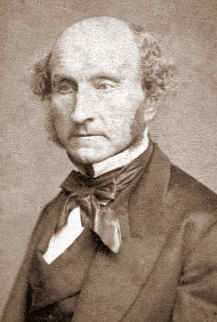

J.S. Mill — photograph by John Watkins, c. 1865

> A stationary condition of capital and population implies no stationary state of human improvement.

Mill, *Principles of Political Economy* (1848), Bk IV, Ch. VI, §2

## The metabolic rift

[figure not shown]

Adolph von Menzel (1815–1905), The Iron Rolling Mill (1875)

## The metabolic rift

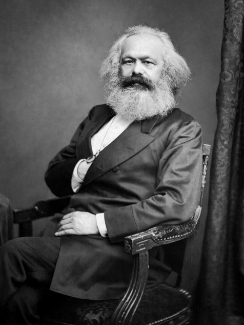

Marx — photograph by John Mayall, 1875

> Capitalist production… disturbs the metabolic interaction between man and the earth.

Karl Marx, Capital, vol. 1 (London: Penguin, 1976), 637–38

## Three theories of value

**Land**

[figure not shown]

Physiocrats

**Labor**

[figure not shown]

Adam Smith — Muir portrait, c. 1800

[figure not shown]

Ricardo — portrait by Thomas Phillips, 1821

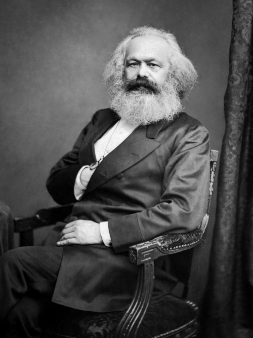

Marx — photograph by John Mayall, 1875

Smith, Ricardo, Marx

**Utility**

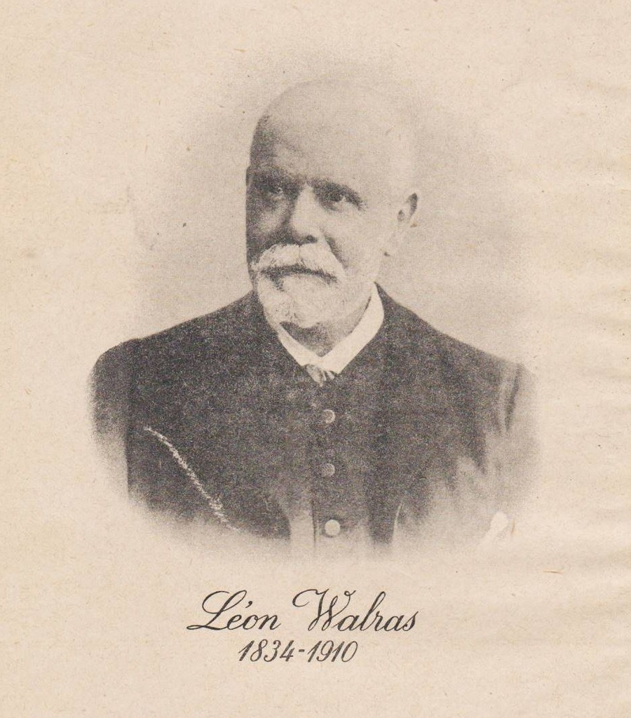

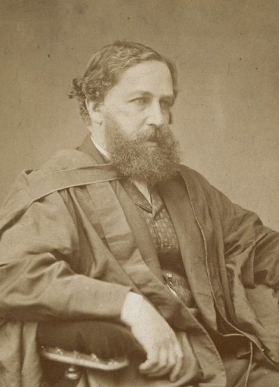

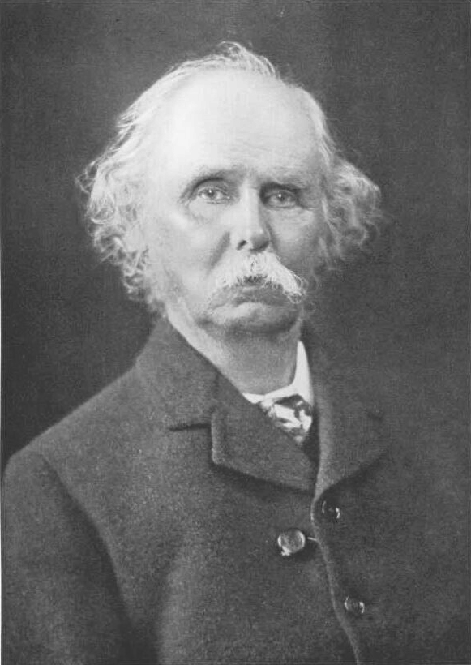

(coming next)

# The “Marginal Revolution”

1870–1950

## Physics envy and the utility move

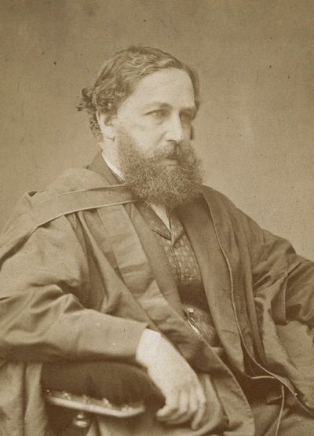

Jevons

> The Theory of Economy… presents a close analogy to the Science of Statical Mechanics.

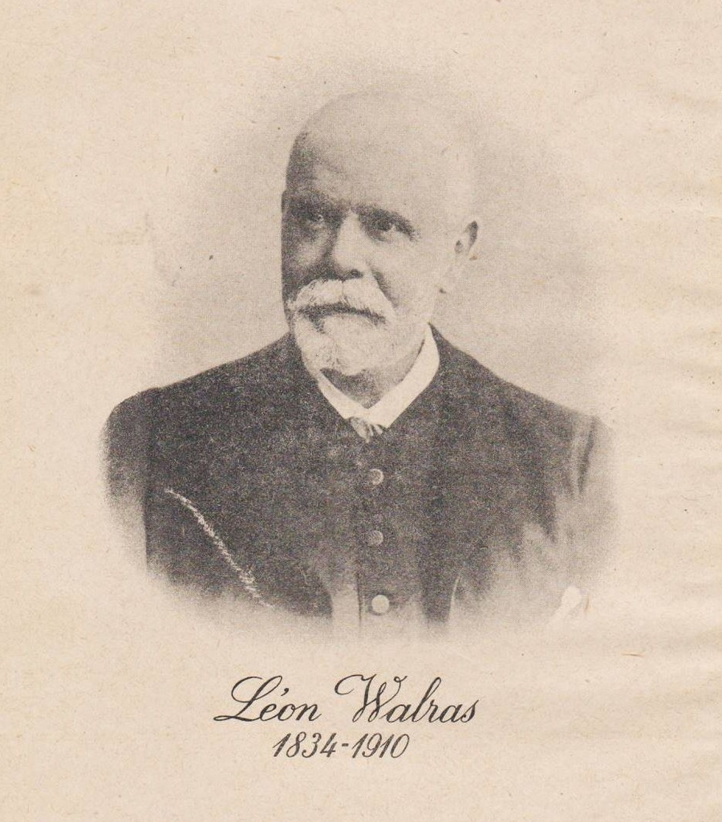

Walras

> The pure theory of economics… resembles the physico-mathematical sciences in every respect.

Jevons (1871), Preface

Walras (1874), §30

## Equilibrium

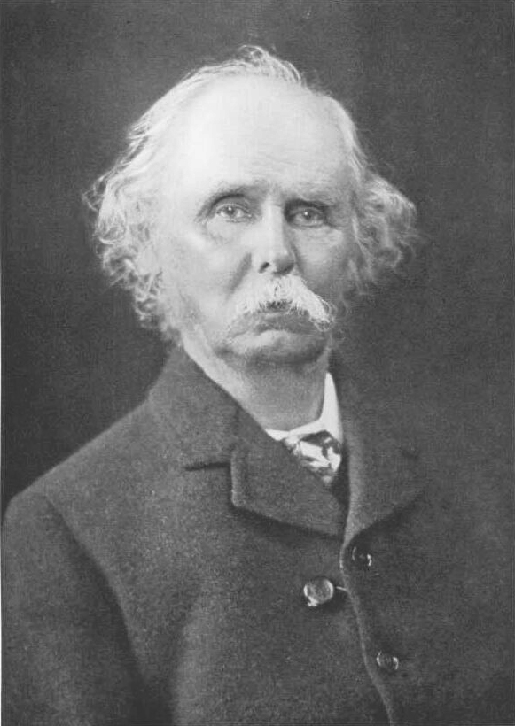

Marshall — photograph c. 1890

> We might as reasonably dispute whether it is the upper or under blade of a pair of scissors that cuts a piece of paper.

Marshall, *Principles of Economics* (1890), Bk V, Ch. III

## What faded away

1. Land
2. Materiality
3. Morality

## The externality patch

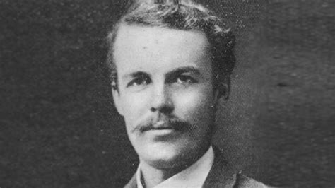

A.C. Pigou — photograph c. 1925

> One person A, in the course of rendering some service, for which payment is made, to a second person B, incidentally also renders services or disservices to other persons . . ., of such a sort that payment cannot be exacted from the benefited parties or compensation enforced on behalf of the injured parties

Pigou, *The Economics of Welfare* (1932)

# Re-entry of nature

1920s–1980

## From cowboy to spaceship

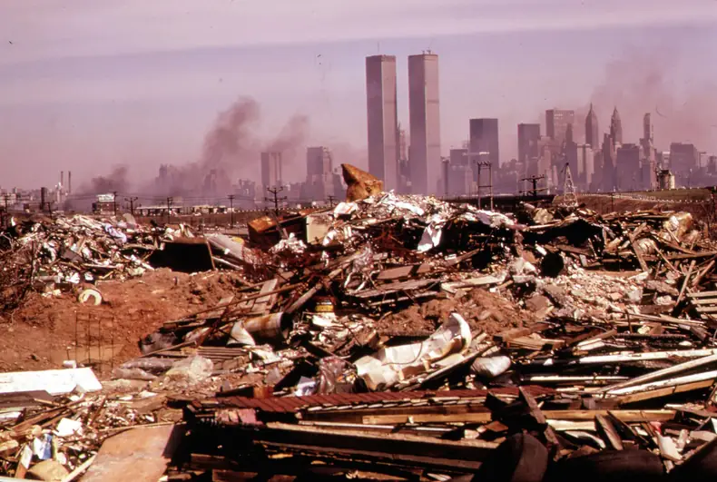

Illegal dumping area — photograph c. 1970

## From cowboy to spaceship

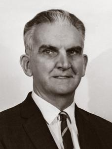

Kenneth Boulding — photograph c. 1965

> Earth has become a single spaceship, without unlimited reservoirs of anything, either for extraction or for pollution.

Boulding, “The Economics of the Coming Spaceship Earth” (1966)

## The entropy law

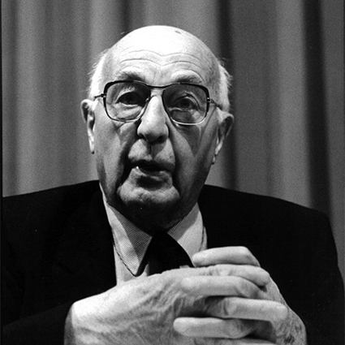

N. Georgescu-Roegen — photograph c. 1975

> Perhaps, the destiny of man is to have a short, but fiery, exciting and extravagant life rather than a long, uneventful and vegetative existence.

Georgescu-Roegen (1971); cf. “Energy and Economic Myths” (1975)

## Limits to Growth

[figure not shown]

*The Limits to Growth* — original 1972 cover

## The steady state, revived

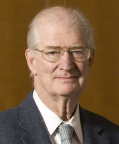

Herman Daly — photograph c. 1995

> Instead the economy is a subsystem of the finite biosphere that supports it.

Daly, *A steady-state economy* (2008)

# Making a Neoliberal World

1947–today

## Markets as information

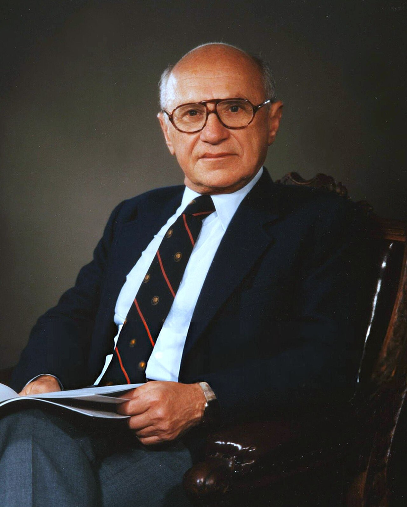

Milton Friedman — photograph 1986

> Only a crisis — actual or perceived — produces real change. When that crisis occurs, the actions that are taken depend on the ideas that are lying around. That, I believe, is our basic function: to develop alternatives to existing policies, to keep them alive and available until the politically impossible becomes the politically inevitable.

Friedman, *Capitalism and Freedom* (1982 [1962]), Preface

## Mont Pèlerin and the long game

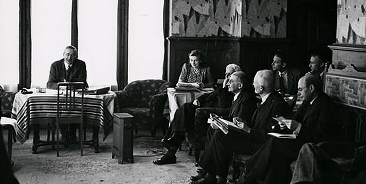

Mont Pèlerin Society, founding meeting, 1947

# Where this leaves us

## Each toolkit answered the questions of its time

## What should 21st-century economics deliver?